[figure not shown]

# Session 3 Exercise: Dimensionality Reduction and Clustering

Author

Rockefeller University, Bioinformatics Resource Centre

Published

These exercises are about LSI, UMAP, clustering, gene activity scores and label transfer in [Single-cell ATAC-seq](https://rockefelleruniversity.github.io/scATAC/).

We carry on with the E18 mouse brain dataset from the Session 2 exercise. Start from your filtered, TF-IDF normalized object (or load ours below).

If you don’t have the object from the Session 2 exercise, download ours into your **data/** folder. It points to the fragment file at `data/atac_v1_E18_brain_flash_5k_fragments.tsv.gz`, so you also need the fragment file and its index there (see the Session 2 exercise).

```r
options(timeout = 600)
download.file(
  url      = "https://www.dropbox.com/scl/fi/ty9ut753rp402fle26h7t/brain_filtered_tfidf.rds?rlkey=ldvv4lhr9xfpa9g422v5lf5vo&st=xe6a0m77&dl=1",
  destfile = "data/brain_filtered_tfidf.rds",
  mode     = "wb"
)
```

Developing brain is very different from blood. Rather than a handful of distinct, well-separated cell types, there is a **continuum**: progenitors in the ventricular zone become intermediate progenitors and then neurons as they migrate outwards. Keep that in mind when you judge your clusters.

**Exercise 1** - **LSI**

- Load the object from the Session 2 exercise and run SVD. Which LSI components should you drop? Check with `DepthCor()`.

[output not shown]

[output not shown]

[output not shown]

[output not shown]

```
Scaling cell embeddings
```

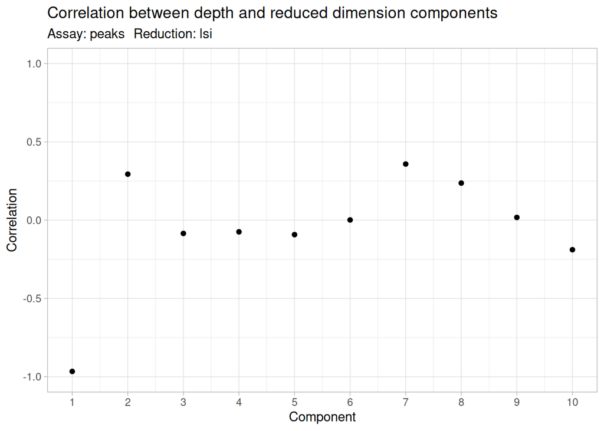

**Exercise 2** - **UMAP**

- Run UMAP on LSI components 2:30 (seed 42) and plot it.

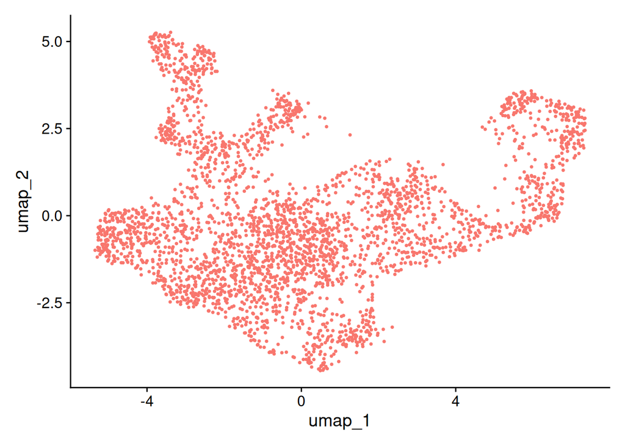

- Now run it again *including* LSI 1 and colour both UMAPs by nCount_peaks. What changes?

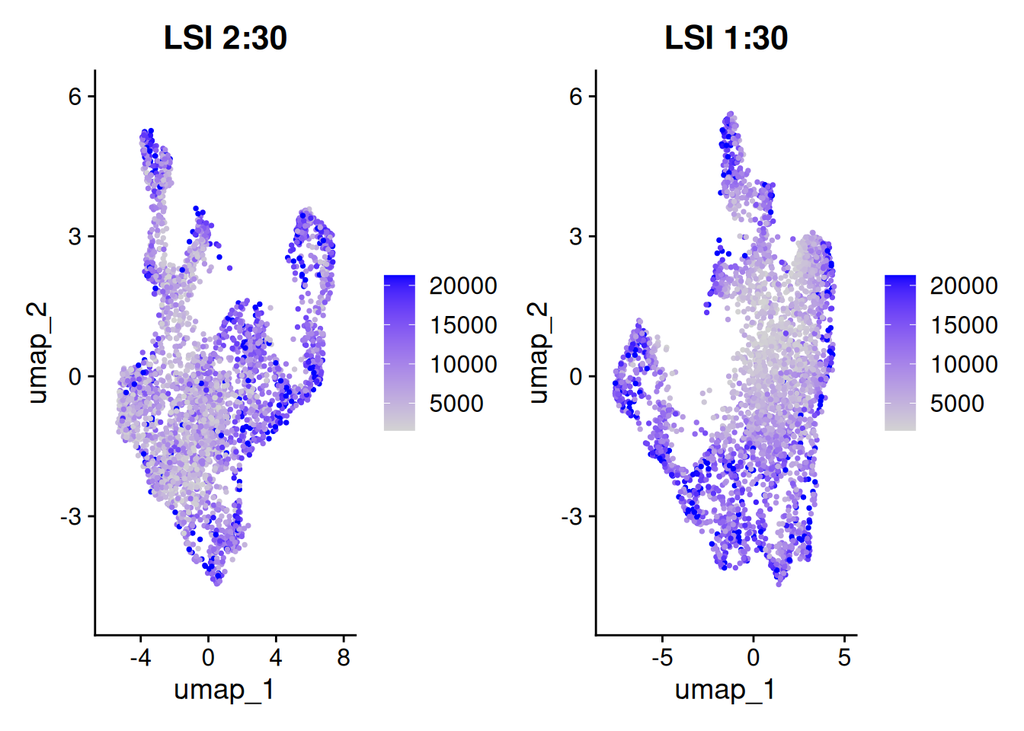

**Exercise 3** - **Clustering**

- Build the neighbour graph on LSI 2:30 and cluster with the SLM algorithm (seed 42) at the default resolution. How many clusters do you get?

```
[1] 8
```

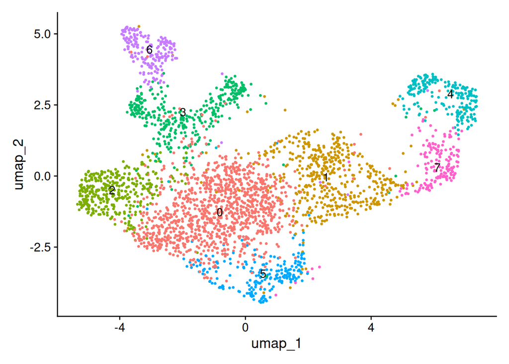

- Try a coarser (0.4) and a finer (1.5) resolution. Given that this tissue is a developmental continuum, what resolution would you pick, and why is there no single right answer?

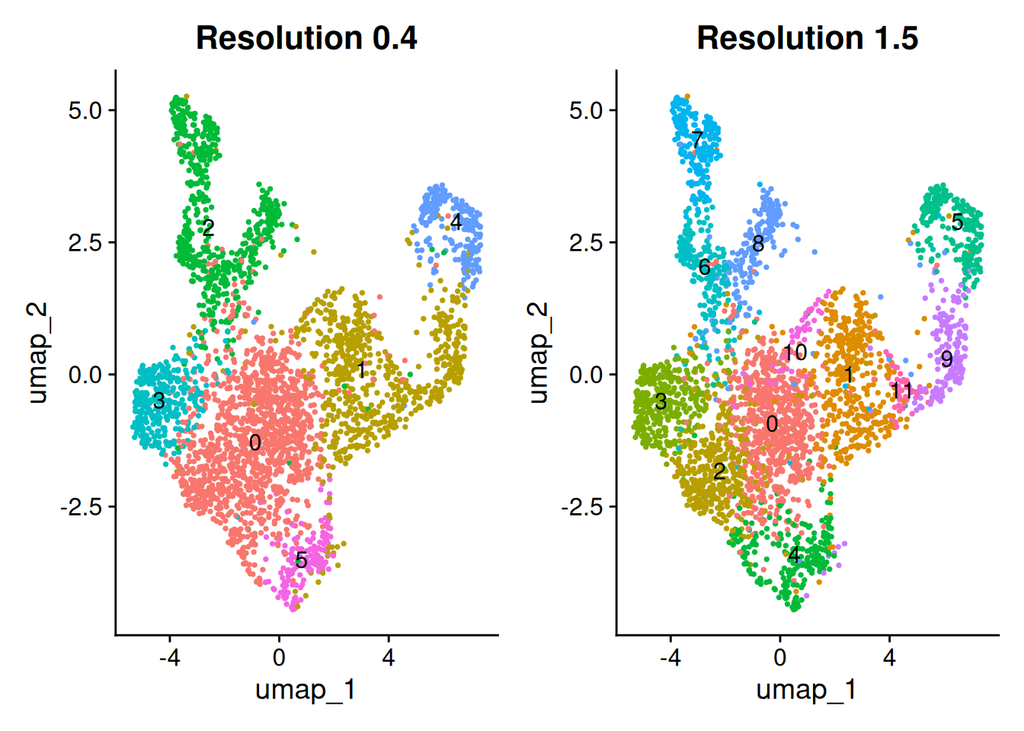

**Exercise 4** - **QC revisited**

- Plot your QC metrics on the UMAP and by cluster. Does any cluster look like it is driven by low quality, or by doublets?

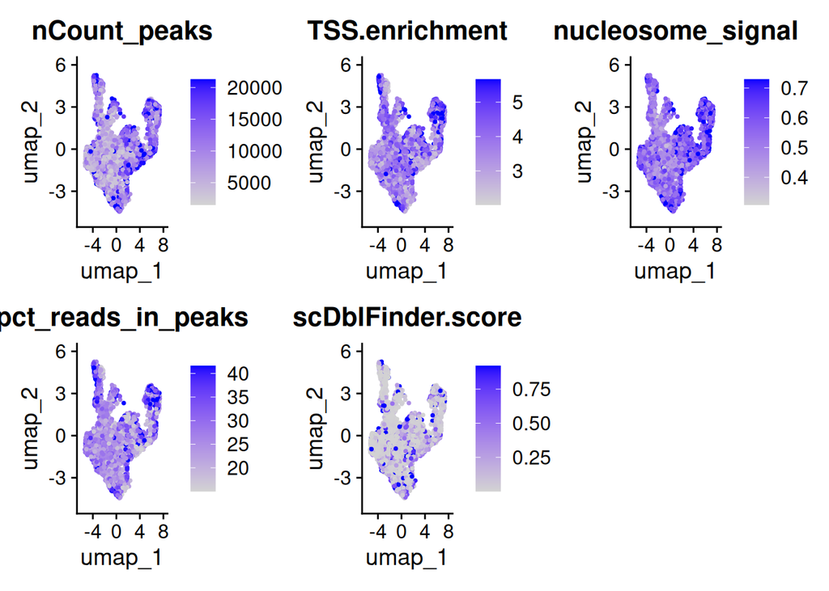

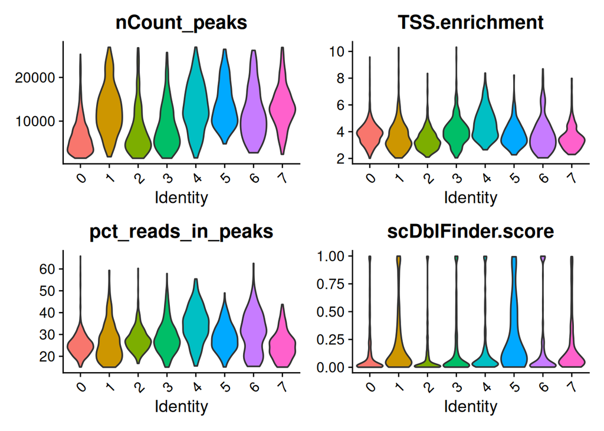

```
    singlet doublet
  0    0.95    0.05
  1    0.91    0.09
  2    0.96    0.04
  3    0.93    0.07
  4    0.92    0.08
  5    0.90    0.10
  6    0.90    0.10
  7    0.93    0.07
```

- In the Session 2 exercise we used a fairly permissive FRiP threshold. Is low FRiP spread evenly, or concentrated in some clusters? What could cause a cell type to have low FRiP without being low quality?

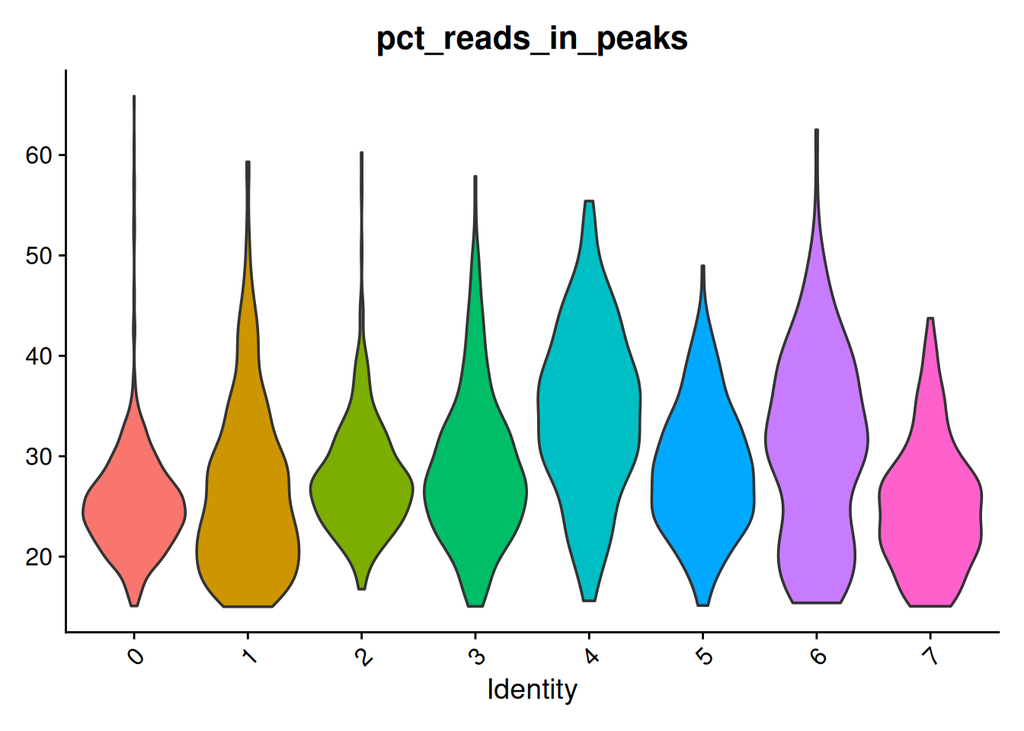

**Exercise 5** - **Gene activity**

- Compute gene activity scores, add them as an “RNA” assay and log-normalize them as in the session.
- Plot gene activity for known markers of the developing cortex. Mouse gene symbols are title case (e.g. *Pax6*, not *PAX6*). Which clusters look like progenitors, which like neurons, and are there any non-neural cells?

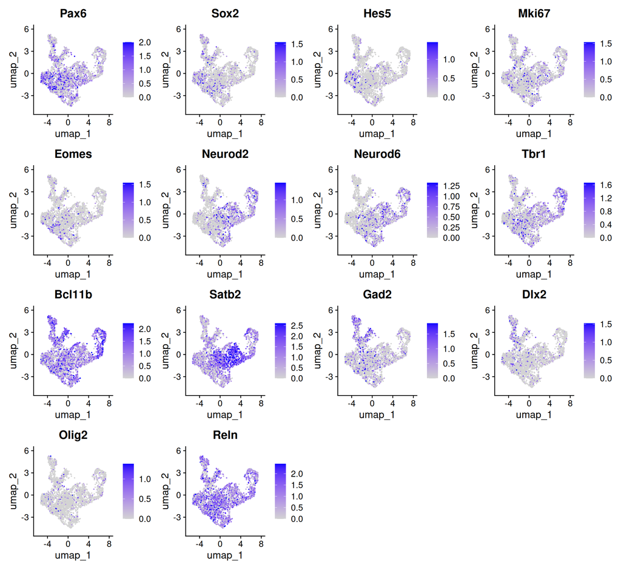

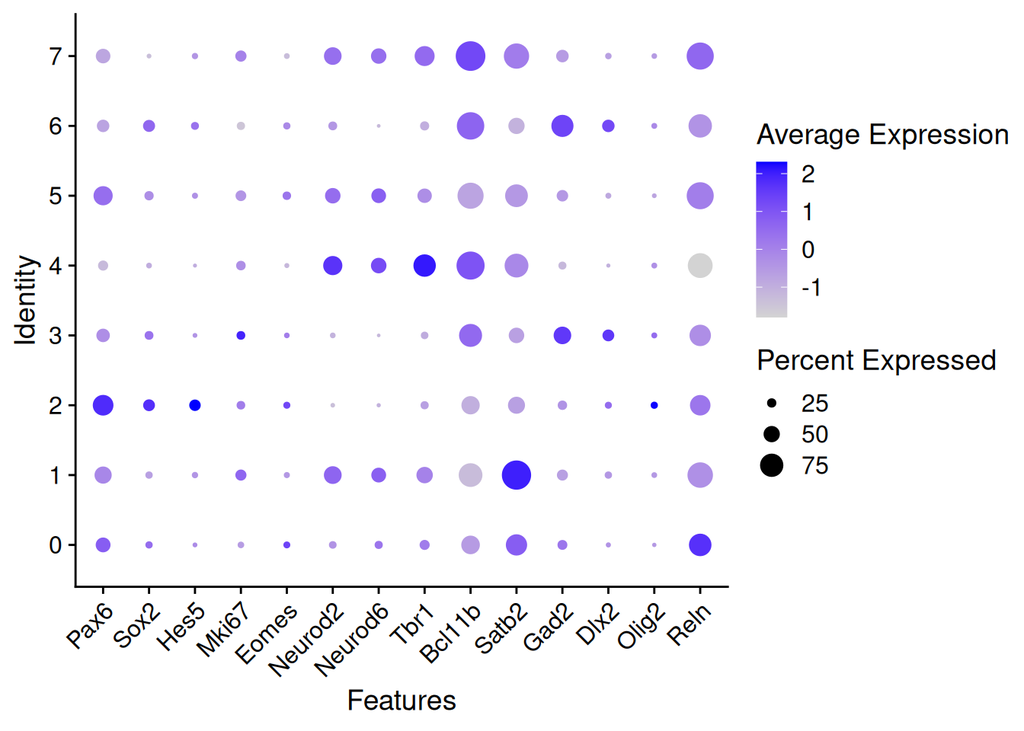

- Give each cluster a provisional label based on the markers. Which clusters are you least confident about?

[output not shown]

```
  cluster             provisional
1      g0           Cajal-Retzius
2      g1  Upper-layer excitatory
3      g2             Radial glia
4      g3             Interneuron
5      g4   Deep-layer excitatory
6      g5 Intermediate progenitor
7      g6             Interneuron
8      g7   Deep-layer excitatory
```

**Exercise 6** - **Label transfer from an imperfect reference**

We don’t have an annotated scRNA-seq reference for E18 mouse brain that is small and freely downloadable. Instead we use the reference from the [Signac mouse brain vignette](https://stuartlab.org/signac/articles/mouse_brain_vignette): scRNA-seq of **adult** mouse cortex from the Allen Institute (~1.2 GB).

```r
options(timeout = 3600)
download.file(
  url      = "https://signac-objects.s3.amazonaws.com/allen_brain.rds",
  destfile = "data/allen_brain.rds",
  mode     = "wb"
)
```

- Before running anything: this is adult cortex and our sample is embryonic cortex, hippocampus and ventricular zone. Which of our cell types do you expect to be **missing** from the reference? What do you think label transfer will do with those cells?
- Load the reference and explore its metadata. How old are the mice, and which brain regions were sampled? Which columns hold cell type labels, and at what level of detail?

```
   Min. 1st Qu.  Median    Mean 3rd Qu.    Max.
  51.00   54.00   56.00   56.72   58.00   91.00
```

```
 VISp
14249
```

```
  Endothelial     GABAergic Glutamatergic  Non-Neuronal
          181          6125          7366           577
```

```
     Astro         CR       Endo    L2/3 IT         L4      L5 IT      L5 PT
       368          7         94        982       1401        880        544
     L6 CT      L6 IT        L6b      Lamp5 Macrophage      Meis2         NP
       960       1872        358       1122         51         45        362
     Oligo       Peri      Pvalb   Serpinf1        SMC       Sncg        Sst
        91         32       1337         27         55        125       1741
       Vip       VLMC
      1728         67
```

- Find transfer anchors between the reference and your gene activity assay, and transfer the `subclass` labels. Use LSI 2:30 for the weighting, as in the session.

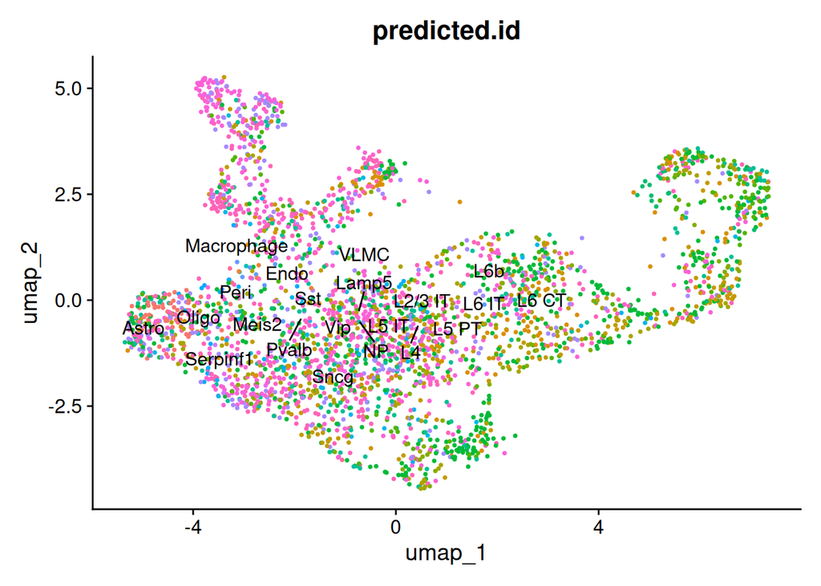

- Look at the prediction scores. Where on the UMAP are the low-confidence cells, and which of your marker-based clusters do they match? Was your prediction right?

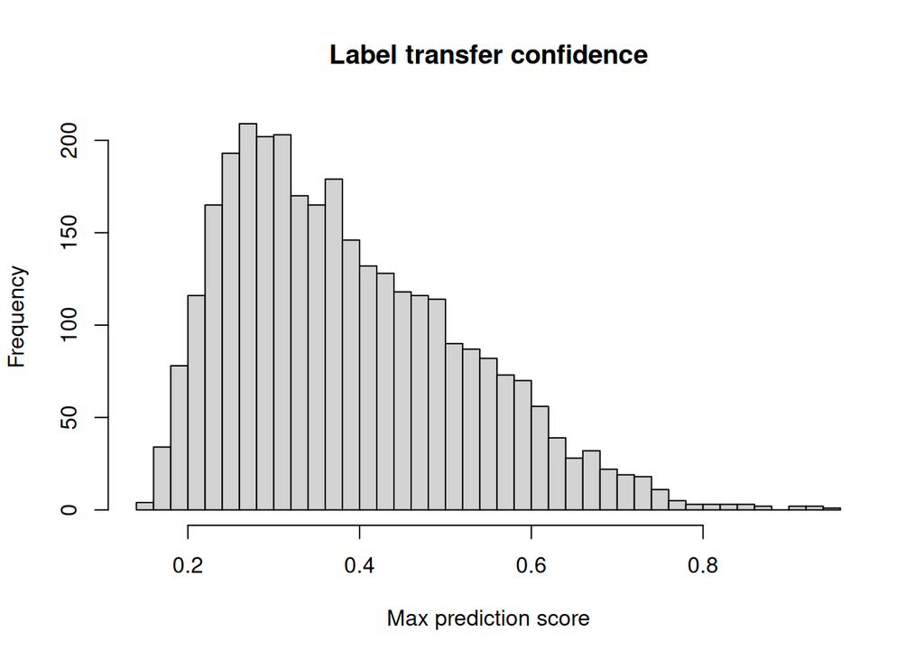

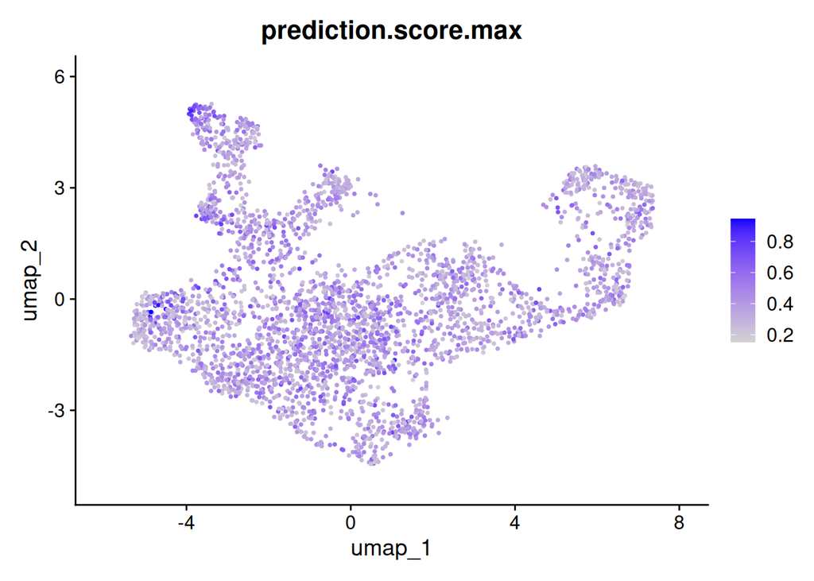

```
        2         4         7         1         3         5         0         6
0.3228653 0.3394451 0.3590764 0.3622391 0.3628091 0.3665954 0.3718710 0.3960704
```

- Cross-tabulate transferred labels against your clusters. Pick one cluster where the transferred label disagrees with your marker-based label. Which do you trust, and why? (Hint: look at how many cells get adult interneuron labels such as Sst, Vip and Pvalb, and compare that with *Gad2*/*Dlx2* activity.)

```
       predicted
cluster Astro Endo L2/3 IT  L4 L5 IT L5 PT L6 CT L6 IT L6b Lamp5 Macrophage
      0     1    1      45 102    54    41    41   126  21    85          1
      1     0    0      47  58    38    17    27   123   4    29          0
      2    65    4       7  11    22     2     4    52   0    39          1
      3     0    0      29  13    10     9     6    39   2    27          2
      4     0    0      20  14    21     3    48    46  21    21          0
      5     0    0       5  17    16    17    13    76   2    14          0
      6     0    0       7   4     6     0     7     9   0     6          2
      7     0    0      17  31    15    11    11    39   1     9          0
       predicted
cluster Meis2  NP Oligo Peri Pvalb Serpinf1 Sncg Sst Vip VLMC
      0     4  34     3    2    98        2   12 237 200    0
      1     0   6     1    3    32        0    2  48  49    1
      2     0   3    16    5    48        1    0  33  57    0
      3     0   7     2    2    23        0    2  67 123    1
      4     0   2     0    0     3        0    0   9  16    0
      5     0   1     1    0     7        0    0  16  26    1
      6     1   0     0    0    42        1    0  87  20    0
      7     0   4     0    0     3        0    0  12  13    0
```

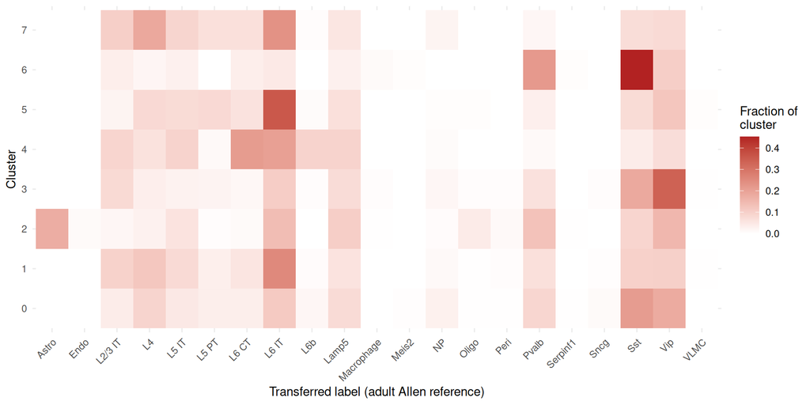

- If you were analyzing this dataset for real, what reference would you look for? What properties does a good reference need?